# Project Python Foundations: FoodHub Data Analysis

#### Observations:

rating is given as an integer although it is as the type float based on previous changes made. 50% of the observations that are not indicated as NaN are rated as 5.

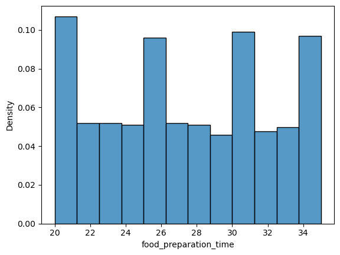

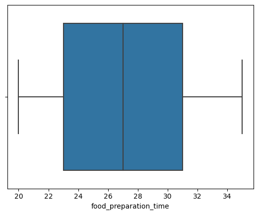

```
<function matplotlib.pyplot.show(close=None, block=None)>
```

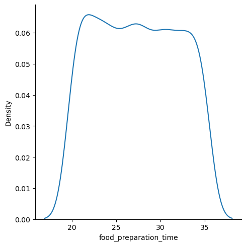

```python
sns.histplot(data = df, x = 'food_preparation_time', stat = 'density')
plt.show()
sns.boxplot(data = df, x = 'food_preparation_time')
plt.show()
sns.displot(data = df, x = 'food_preparation_time', kind = 'kde')
plt.show
```

#### Observations:

50% of the observations for food_preparation_time have a value between 23 and 31 with a range from 20 minutes to 35 minutes.

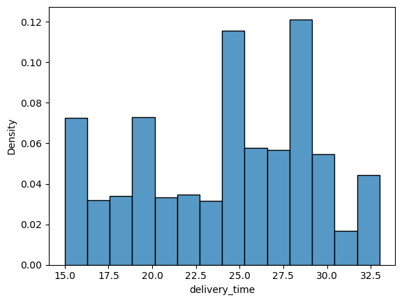

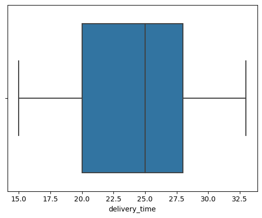

```
<function matplotlib.pyplot.show(close=None, block=None)>
```

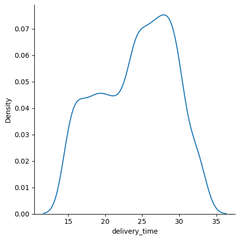

```python
sns.histplot(data = df, x = 'delivery_time', stat = 'density')
plt.show()
sns.boxplot(data = df, x = 'delivery_time')
plt.show()
sns.displot(data = df, x = 'delivery_time', kind = 'kde')
plt.show
```

#### Observations:

[output not shown]

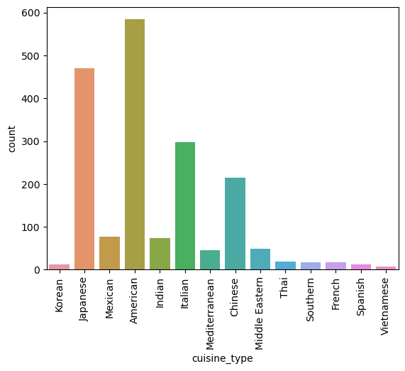

```python
# Visualize categorical variables 'cuisine_type' and 'day_of_the_week'
sns.countplot(data=df, x = 'cuisine_type')
plt.xticks(rotation=90)
```

#### Observations:

The most popular cuisines in the sample are American, Japanese, Italian and Chinese.

```
(array([0, 1]), [Text(0, 0, 'Weekend'), Text(1, 0, 'Weekday')])
```

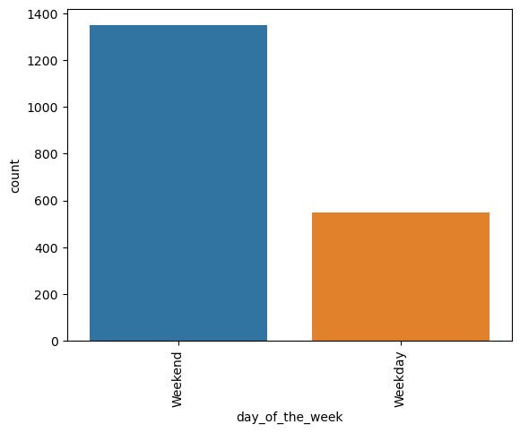

```python
sns.countplot(data=df, x = 'day_of_the_week')
plt.xticks(rotation=90)
```

#### Observations:

Weekend orders make up over 1,300 observations while weekday orders make up approximately 550 observations.

### **Question 7**: Which are the top 5 restaurants in terms of the number of orders received? [1 mark]

```python
# Find value counts by restaurant_name
df.restaurant_name.value_counts()
```

```
Shake Shack                  219
The Meatball Shop            132
Blue Ribbon Sushi            119
Blue Ribbon Fried Chicken     96
Parm                          68
                            ...
Sushi Choshi                   1
Dos Caminos Soho               1
La Follia                      1
Philippe Chow                  1
'wichcraft                     1
Name: restaurant_name, Length: 178, dtype: int64
```

#### Observations:

Shake Shack has the most orders in the sample at 219, followed by The Meatball Shop at 132, Blue Ribbon Sushi at 119, Blue Ribbon Fried Chicken at 96 and Parm at 68.

### **Question 8**: Which is the most popular cuisine on weekends? [1 mark]

```python
# Find value counts by cuisine type where day_of_the_week is 'Weekend'
df.loc[df['day_of_the_week']=="Weekend"].cuisine_type.value_counts()
```

```
American          415
Japanese          335
Italian           207
Chinese           163
Mexican            53
Indian             49
Mediterranean      32
Middle Eastern     32
Thai               15
French             13
Korean             11
Southern           11
Spanish            11
Vietnamese          4
Name: cuisine_type, dtype: int64
```

#### Observations:

American is the most popular cuisine on the weekends, representing 415 weekend orders.

### **Question 9**: What percentage of the orders cost more than 20 dollars? [2 marks]

```python
#Find the count of orders costing more than 20 dollars and divide by the total number of orders to get the percentage.
df.loc[df['cost_of_the_order']>20].order_id.count()/df.shape[0]
```

```
0.2924130663856691
```

#### Observations:

555 out of 1,898 orders cost over 20 dollars, or 29.2%.

### **Question 10**: What is the mean order delivery time? [1 mark]

```python
#Apply method mean() to all observations of 'delivery_time'
df['delivery_time'].mean()
```

```
24.161749209694417
```

#### Observations:

The mean order delivery time is 24.16 minutes.

### **Question 11:** The company has decided to give 20% discount vouchers to the top 3 most frequent customers. Find the IDs of these customers and the number of orders they placed. [1 mark]

```python
#Find value counts by 'customer_id'
df.customer_id.value_counts()
```

```
52832     13
47440     10
83287      9
250494     8
259341     7
          ..
385426     1
254913     1
289597     1
74412      1
397537     1
Name: customer_id, Length: 1200, dtype: int64
```

#### Observations:

Customers 52832, 47440 and 83287 had the greatest number of orders at 13, 10 and 9 orders, respectively.

### **Question 12**: Perform a multivariate analysis to explore relationships between the important variables in the dataset. (It is a good idea to explore relations between numerical variables as well as relations between numerical and categorical variables) [10 marks]

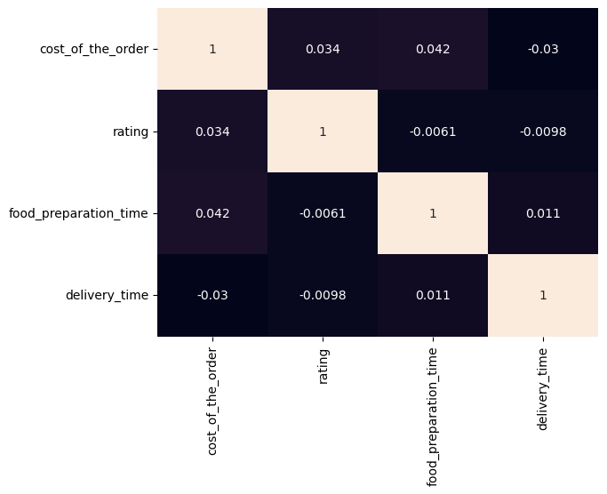

```python
#Find correlations between all numerical columns
sns.heatmap(data = df[['cost_of_the_order', 'rating','food_preparation_time', 'delivery_time']].corr(), annot=True, cbar=False)
```

#### Observations:

Correlations between numerical fields in the data frame are quite small in magnitude. All correlations have and absolute value under 0.05.

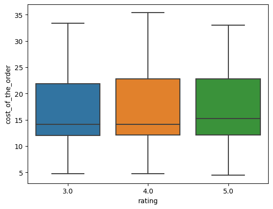

```python
# Create a visualization of cost_of_the_order by rating
sns.boxplot(data=df,x='rating', y='cost_of_the_order',showfliers=False)
```

#### Observations:

Overall, the cost of the order is not substantially different based on rating. Orders with 5 ratings have the highest median value however.

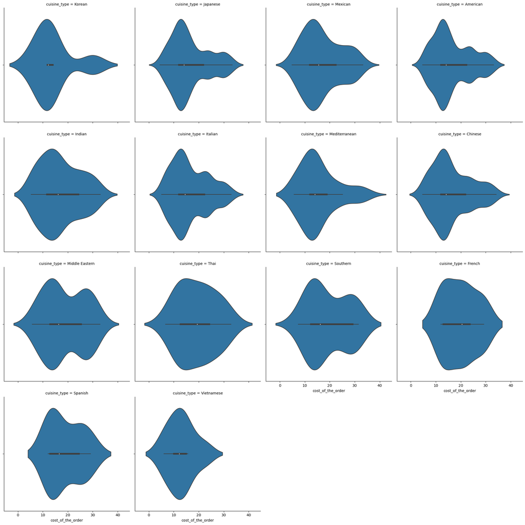

```python
#Create violin plots of cost_of_the_order by cuisine_type
sns.catplot(x='cost_of_the_order',
            col='cuisine_type',
            data=df,
            col_wrap=4,
            kind="violin")
plt.show()
```

#### Observations:

With regards to cost of the order, most cuisine types appear to be skewed to the right. The median cost of the order for French and Thai cuisine appear to be the highest at around 20 dollars. The IQR appears to be largest for Southern cusisine.

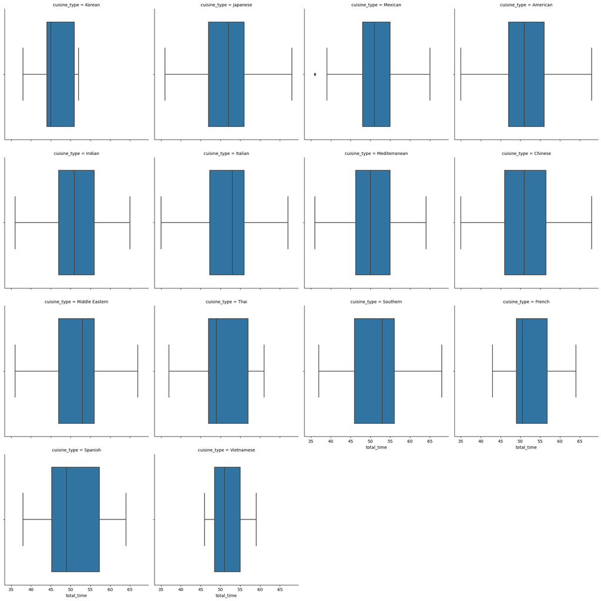

```python
#create a new variable named 'total time' and plot total_time by cuisine_type
df['total_time'] = df['food_preparation_time'] + df['delivery_time']
sns.catplot(x='total_time',
            col='cuisine_type',
            data=df,
            col_wrap=4,
            kind="box")
plt.show()
```

#### Observations:

Total time for food preparation and delivery is shortest for Korean with a median total_time of 45 minutes. Other cuisines differ some but for the most part are comparable in terms of total_time.

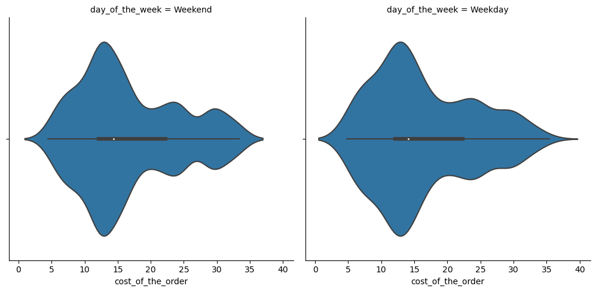

```python
#Plot cost_of_the_order by day_of_the_week using a violin catplot
sns.catplot(x='cost_of_the_order',
            col='day_of_the_week',
            data=df,
            col_wrap=4,
            kind="violin")
plt.show()
```

#### Conclusions:

Based on the plots above, cost_of_the_order does not vary significantly between weekends and weekdays.

### **Question 13:** The company wants to provide a promotional offer in the advertisement of the restaurants. The condition to get the offer is that the restaurants must have a rating count of more than 50 and the average rating should be greater than 4. Find the restaurants fulfilling the criteria to get the promotional offer. [3 marks]

```python
# Mean rating value
df1 = df.groupby(['restaurant_name'])

# Create new data frame to find mean rating for each restaurant
df2 = df1.agg(mean_rating =('rating', np.mean))

#Assign a new variable mean_rating_gt_4 as 1 if true and 0 if false
df2['mean_rating_gt_4'] = np.where(df2['mean_rating']>4, 1, 0)
```

```python
# Count of ratings
# Create a new data frme to find number of ratings for each restaurant
df3 = df1.agg(rating_count = ('rating', np.count_nonzero))

# Assign a new variable rating_count_gt_50 as 1 if true and 0 if false
df3['rating_count_gt_50'] = np.where(df3['rating_count']>50, 1,0)
```

```python
#Merge df2 and df3 on restaurant_name
df4 = pd.merge(df2,df3,how='left',on='restaurant_name')

df4
```

| restaurant_name | mean_rating | mean_rating_gt_4 | rating_count | rating_count_gt_50 |
| --- | --- | --- | --- | --- |
| 'wichcraft | 5.000000 | 1 | 1 | 0 |
| 12 Chairs | 4.500000 | 1 | 4 | 0 |
| 5 Napkin Burger | 4.000000 | 0 | 5 | 0 |
| 67 Burger | 5.000000 | 1 | 1 | 0 |
| Alidoro | NaN | 0 | 1 | 0 |
| ... | ... | ... | ... | ... |
| Zero Otto Nove | 4.000000 | 0 | 2 | 0 |
| brgr | 3.000000 | 0 | 2 | 0 |
| da Umberto | 5.000000 | 1 | 3 | 0 |
| ilili Restaurant | 4.153846 | 1 | 18 | 0 |
| indikitch | 4.500000 | 1 | 4 | 0 |

178 rows × 4 columns

```python
# If mean_rating_gt_4 = 1 and rating_count_gt_50 = 1, both conditions are satisfied.
# A new variable is created named 'promotion' in df4

def promotion(row):
  if row['mean_rating_gt_4'] == 1 and row['rating_count_gt_50'] == 1:
    return 1
  else:
    return 0

df4['promotion'] = df4.apply(promotion, axis = 1)

# Sort by the indicator variable named 'promotion'
df4.sort_values(by=['promotion'], inplace=True)

# Find the restaurants with a value of 1 for 'promotion'
df4.tail(n=20)
```

| restaurant_name | mean_rating | mean_rating_gt_4 | rating_count | rating_count_gt_50 | promotion |
| --- | --- | --- | --- | --- | --- |
| Waverly Diner | 3.750000 | 0 | 7 | 0 | 0 |
| Tortaria | 5.000000 | 1 | 4 | 0 | 0 |
| Westville Hudson | 4.555556 | 1 | 15 | 0 | 0 |
| Wa Jeal | NaN | 0 | 1 | 0 | 0 |
| Xe May Sandwich Shop | 5.000000 | 1 | 2 | 0 | 0 |
| Xi'an Famous Foods | 4.285714 | 1 | 9 | 0 | 0 |
| Yama 49 | 5.000000 | 1 | 5 | 0 | 0 |
| Yama Japanese Restaurant | 4.500000 | 1 | 18 | 0 | 0 |
| Zero Otto Nove | 4.000000 | 0 | 2 | 0 | 0 |
| brgr | 3.000000 | 0 | 2 | 0 | 0 |
| da Umberto | 5.000000 | 1 | 3 | 0 | 0 |
| Wo Hop Restaurant | 4.000000 | 0 | 1 | 0 | 0 |
| Woorijip | 3.000000 | 0 | 1 | 0 | 0 |
| Parm | 4.128205 | 1 | 68 | 1 | 1 |
| RedFarm Broadway | 4.243902 | 1 | 59 | 1 | 1 |
| RedFarm Hudson | 4.176471 | 1 | 55 | 1 | 1 |
| Shake Shack | 4.278195 | 1 | 219 | 1 | 1 |
| Blue Ribbon Fried Chicken | 4.328125 | 1 | 96 | 1 | 1 |
| Blue Ribbon Sushi | 4.219178 | 1 | 119 | 1 | 1 |
| The Meatball Shop | 4.511905 | 1 | 132 | 1 | 1 |

### **Question 14:** The company charges the restaurant 25% on the orders having cost greater than 20 dollars and 15% on the orders having cost greater than 5 dollars. Find the net revenue generated by the company across all orders. [3 marks]

```python
# Create a function named revenue. If cost_of_the_order is > 20 then revenue for that order is 25% of the cost of the order.
# For all remaining orders, if cost_of_the_order is > 5 then revenue for that order is 15% of the cost of the order.

def revenue(row):
  if row['cost_of_the_order'] > 20:
    return row['cost_of_the_order'] * 0.25
  elif row['cost_of_the_order'] > 5:
    return row['cost_of_the_order'] * 0.15

# Create new column to capture revenue for each order
df['revenue'] = df.apply(revenue, axis = 1)

# Sum revenue across orders
df['revenue'].sum()
```

```
6166.303
```

#### Observations:

Total revenue for the company during the sample period is 6,166 dollars.

### **Question 15:** The company wants to analyze the total time required to deliver the food. What percentage of orders take more than 60 minutes to get delivered from the time the order is placed? (The food has to be prepared and then delivered.) [2 marks]

```python
# The variable total_time was calculated already above.
# Find number of orders with total_time > 60 and divide by the total number of orders in the data frame.

df.loc[df['total_time']>60].count()/df.shape[0]
```

```
order_id                 0.105374
customer_id              0.105374
restaurant_name          0.105374
cuisine_type             0.105374
cost_of_the_order        0.105374
day_of_the_week          0.105374
rating                   0.062698
food_preparation_time    0.105374
delivery_time            0.105374
total_time               0.105374
revenue                  0.104320
dtype: float64
```

#### Observations:

200 out of 1,898, or 10.5% of all orders take more than 60 minutes in total_time (i.e., food_preparation_time + delivery_time).

### **Question 16:** The company wants to analyze the delivery time of the orders on weekdays and weekends. How does the mean delivery time vary during weekdays and weekends? [2 marks]

```python
# Group by day_of_the_week and find mean delivery_time for weekday and weekend
df.groupby(['day_of_the_week'])['delivery_time'].mean()
```

```
day_of_the_week
Weekday    28.340037
Weekend    22.470022
Name: delivery_time, dtype: float64
```

#### Observations:

Mean delivery time is greater on weekdays at 28.3 minutes compared to a mean delivery time on weekends of 22.5 minutes.

### Conclusion and Recommendations

### **Question 17:** What are your conclusions from the analysis? What recommendations would you like to share to help improve the business? (You can use cuisine type and feedback ratings to drive your business recommendations.) [6 marks]

### Conclusions:

- The most popular cuisines in the sample are American, Japanese, Italian and Chinese. This pattern generally holds for both weekends and weekdays.
- 736 out of 1,898 orders were not rated. 588 were given a 5 rating, 386 were given a 4 rating and 188 were given a 3 rating.
- Only 7 restaurants qualify for promotional offer with average rating over 4 and order count over 50.